# Chapter 4 Homework Solutions

Ali Raisolsadat

2026-03-28

### Chapter 4 - Lecture 1

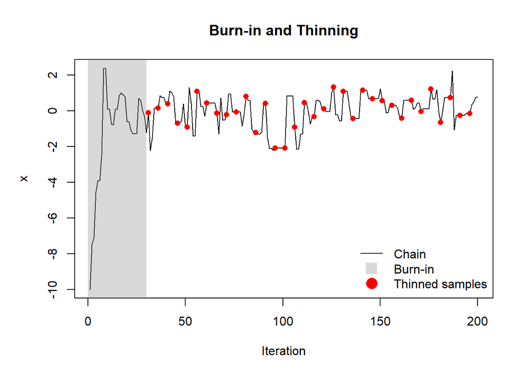

```r
target_density <- function(x) {
  # target density for the Metropolis algorithm
  return(exp(-0.5 * x^2))
}

metropolis_step <- function(p, x, proposal_std) {
  # propose a new state using Gaussian random walk
  x_hat <- x + rnorm(1, mean = 0, sd = proposal_std)

  # compute acceptance probability
  alpha <- min(1, p(x_hat) / p(x))

  # accept or reject the proposal
  u <- runif(1, 0, 1)

  if (u < alpha) {
    x <- x_hat  # accept
  }

  return(x)
}

# initialize a single chain
set.seed(0)
n_steps <- 200
proposal_std <- 2
x <- numeric(n_steps)
x[1] <- -10

# simulate a single chain
for (t in 2:n_steps) {
  x[t] <- metropolis_step(target_density, x[t-1], proposal_std)
}

# plot
# increase margins for large figure
par(mar = c(5,5,4,2))
plot(x,type = "l", lwd = 1, xlab = "Iteration", ylab = "x", main = "Burn-in and Thinning")
usr <- par("usr")
rect(xleft = 0, ybottom = usr[3], xright = 30, ytop = usr[4], col = rgb(0.5, 0.5, 0.5, 0.3), border = NA)
points(seq(31, n_steps, by = 5), x[seq(31, n_steps, by = 5)], col = "red", pch = 16)
legend("bottomright", legend = c("Chain", "Burn-in", "Thinned samples"),
       col = c("black", rgb(0.5,0.5,0.5,0.3), "red"),
       lty = c(1, NA, NA), pch = c(NA, 15, 16), pt.cex = 2, bty = "n"
)
```

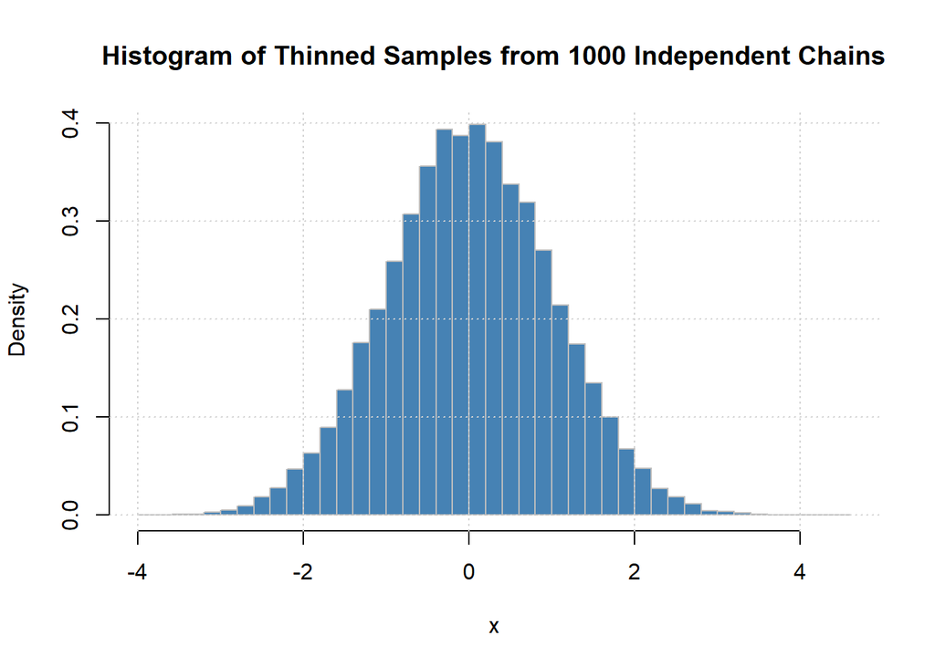

```r
# simulation parameters
n_chains <- 1000       # number of independent chains
burn_in <- 30
thin <- 5
chains <- runif(n_chains, -10, 10)

# run chains and collect thinned samples
thinned_samples <- c()

for (t in 1:n_steps) {
  for (i in 1:n_chains) {
    chains[i] <- metropolis_step(target_density, chains[i], proposal_std)
  }

  # after burn-in, collect thinned samples
  if (t > burn_in && (t - burn_in) %% thin == 0) {
    thinned_samples <- c(thinned_samples, chains)
  }
}

# plot histogram of thinned samples
hist(thinned_samples, breaks = 50, probability = TRUE, col = "steelblue", border = "gray",
     main = paste("Histogram of Thinned Samples from", n_chains, "Independent Chains"),
     xlab = "x", ylab = "Density"
)
grid()
```

### Comment on the Histogram

After running many independent chains, applying burn-in and thinning, the combined thinned samples form a histogram that approximates the target distribution.

The histogram shows the probability density of the target, with higher frequencies where the distribution has higher probability (near the mean, lower spread in the tails).

This demonstrates the key property of MCMC: even though individual samples are dependent and start from different points, after burn-in and with sufficient sampling, the collected samples are effectively drawn from the stationary distribution.

### Chapter 4 Homework - Lecture 2

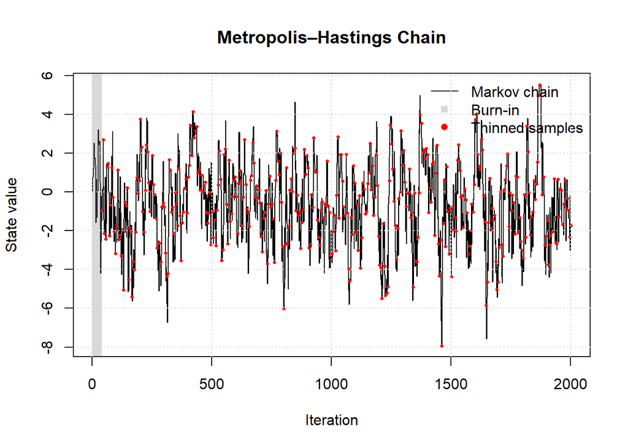

```r
# target distribution
target <- function(x) {
  return(exp(-x^2 / 8))
}

# asymmetric proposal mechanism for Metropolis Hastings
proposal_fn <- function(x, step_size = 1.0) {
  if (runif(1) < 0.7) {
    return(rnorm(1, mean = x + step_size, sd = 1))
  } else {
    return(rnorm(1, mean = x - step_size, sd = 1))
  }
}

# evaluate proposal density q(x_new | x_old)
proposal_density_fn <- function(x_new, x_old, step_size = 1.0) {
  return(
    0.7 * dnorm(x_new, mean = x_old + step_size, sd = 0.5) +
    0.3 * dnorm(x_new, mean = x_old - step_size, sd = 0.5)
  )
}

# Metropolis Hastings algorithm
metropolis_hastings <- function(target, T = 5000, x0 = 0.0,
                                proposal_fn = NULL, proposal_density_fn = NULL, step_size = 0.8) {
  # initialize chain storage
  x <- numeric(T + 1)
  x[1] <- x0

  for (t in 2:(T + 1)) {
    # propose a new candidate
    x_prop <- proposal_fn(x[t - 1], step_size)

    # compute acceptance ratio
    numerator <- target(x_prop)
    denominator <- target(x[t - 1])

    # if asymmetric proposal include ratio
    if (!is.null(proposal_density_fn)) {
      numerator <- numerator *
        proposal_density_fn(x[t - 1], x_prop, step_size)

      denominator <- denominator *
        proposal_density_fn(x_prop, x[t - 1], step_size)
    }

    alpha <- min(1, numerator / denominator)

    # acceptance condition
    if (runif(1) < alpha) {
      x[t] <- x_prop
    } else {
      x[t] <- x[t - 1]
    }
  }

  return(x)
}


# MCMC settings
T <- 2000
burn_in <- 40
thinning <- 5


# run a single Metropolis–Hastings chain
x_single <- metropolis_hastings(target = target,T = T,x0 = 0,
                                proposal_fn = proposal_fn,
                                proposal_density_fn = proposal_density_fn,
                                step_size = 1.0
)


# burn-in and thinning
post_burnin <- x_single[(burn_in + 1):length(x_single)]
thin_idx <- seq(1, length(post_burnin), by = thinning)
thinned_samples <- post_burnin[thin_idx]
thinned_iters <- thin_idx + burn_in


# plot
plot(x_single,type = "l",lwd = 1, main = "Metropolis–Hastings Chain", xlab = "Iteration", ylab = "State value")

# burn-in shading
usr <- par("usr")
rect(xleft = 0, ybottom = usr[3], xright = burn_in, ytop = usr[4], col = rgb(0.5, 0.5, 0.5, 0.3), border = NA)
points(thinned_iters, thinned_samples, col = "red", pch = 16, cex = 0.5)
legend("topright", legend = c("Markov chain", "Burn-in", "Thinned samples"),
       col = c("black", rgb(0.5,0.5,0.5,0.3), "red"),
       lty = c(1, NA, NA), pch = c(NA, 15, 16), pt.cex = 1, bty = "n"
)
grid()
```

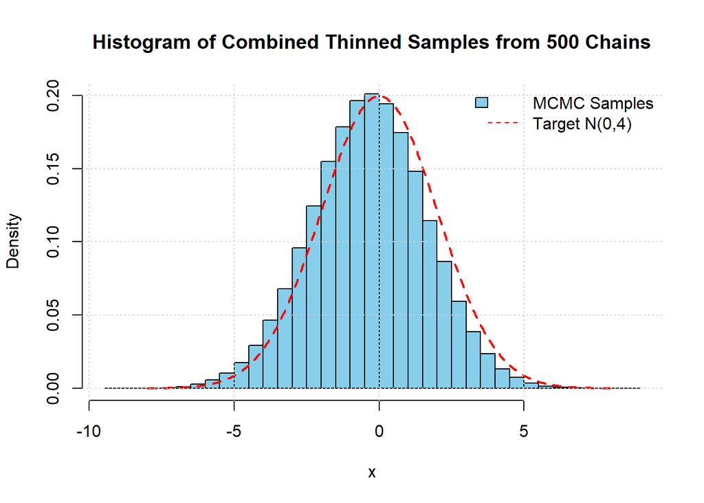

```r
# multiple independent MCMC chains
num_chains <- 500              # number of chains to simulate
start_range <- c(-4, 8)        # range for random initialization (overdispersed)
all_samples <- numeric(0)

for (i in 1:num_chains) {
  x0 <- runif(1, start_range[1], start_range[2])
  chain <- metropolis_hastings(target, T, x0, proposal_fn,proposal_density_fn, 1.0)
  post_burnin <- chain[(burn_in + 1):length(chain)]
  all_samples <- c(all_samples, post_burnin[seq(1, length(post_burnin), by = thinning)])
}

# plot histogram
hist(all_samples, breaks = 50, probability = TRUE, col = "skyblue", border = "black",
  main = "Histogram of Combined Thinned Samples from 500 Chains",
  xlab = "x", ylab = "Density"
)

# overlay true density N(0,4)
x_vals <- seq(-8, 8, length.out = 500)
lines(x_vals, dnorm(x_vals, mean = 0, sd = 2), col = "red", lwd = 2, lty = 2)
legend("topright", legend = c("MCMC Samples", "Target N(0,4)"),
       fill = c("skyblue", NA), border = c("black", NA), lty = c(NA, 2), col = c(NA, "red"), bty = "n"
)

grid()
```

### Hybrid Estimator Example - Online Retailer Sales

An online retailer collects daily sales data (in thousands of dollars) for a certain product:
$$x = (x_1, x_2, \dots, x_n)$$

The retailer wants to estimate the mean sales but is concerned about extreme high sales skewing the average. To improve accuracy, a **hybrid bootstrap estimator** is proposed:

- The **lower 90% of sales** (non-extreme) are resampled nonparametrically.
- The **top 10% of sales** (extreme values) are resampled parametrically using a Normal distribution fitted to the top 10% of the data.

Your task is to estimate the **bias** and **standard deviation** of the hybrid mean using $N$ bootstrap samples.

### Pseudocode: Hybrid Bootstrap Estimator for Mean Sales

**Input:** Data $x = (x_1, \dots, x_n)$, number of bootstrap samples $N$  
**Output:** Bias and standard deviation estimates of hybrid mean

1. Sort $x$ and define threshold $u$ as the $90\%$ empirical quantile
2. Split the data:
   - `lower_data` = values $\leq u$
   - `top_data` = values $> u$
3. Fit a Normal distribution to `top_data` to get mean $\mu_\text{top}$ and standard deviation $\sigma_\text{top}$
4. Compute the hybrid mean on the original data:
   $$\hat{\theta}_n(x) = \text{mean}(\text{lower_data} \cup \text{top_data})$$
5. Initialize array $\theta^*$ to store bootstrap estimates
6. **For** $b = 1$ to $N$:
   1. Draw bootstrap sample from `lower_data` (nonparametric)
   2. Simulate bootstrap sample from Normal($\mu_\text{top}, \sigma_\text{top}$) for `top_data`
   3. Combine lower and top bootstrap samples to form $x_b^*$
   4. Compute hybrid mean $\hat{\theta}_b^*$ from $x_b^*$
7. Compute bias estimate:
   $$\text{Bias}(\hat{\theta}_n) = \frac{1}{N}\sum_{b=1}^N \hat{\theta}_b^* -
   \hat{\theta}_n$$
8. Compute standard deviation:
   $$\text{s.d.}(\hat{\theta}_n) = \sqrt{\frac{1}{N-1} \sum_{b=1}^N
   \left(\hat{\theta}_b^* - \overline{\hat{\theta}^*}\right)^2}$$
9. **Return** bias and standard deviation estimates

```r
hybrid_bootstrap <- function(x, alpha0, N) {
  x <- as.numeric(x)

  # step 1: threshold for hybrid estimator
  u <- quantile(x, alpha0)
  lower_data <- x[x <= u]  # lower 90% nonparametric
  top_data <- x[x > u]     # upper 10% parametric

  # step 2: parameters for parametric top 10%
  mu_top <- mean(top_data)
  sigma_top <- sd(top_data)

  # step 3: hybrid mean on original data
  theta_hat <- mean(c(lower_data, top_data))

  # step 4: Bootstrap loop
  theta_star <- numeric(N)

  for (b in 1:N) {

    # resample lower 90% nonparametrically
    lower_sample <- sample(lower_data,  size = length(lower_data), replace = TRUE)

    # simulate top 10% parametrically
    top_sample <- rnorm(length(top_data), mean = mu_top, sd = sigma_top)

    # combine lower and top
    x_star <- c(lower_sample, top_sample)

    # hybrid mean for bootstrap sample
    theta_star[b] <- mean(x_star)
  }

  # step 5: bias and standard deviation
  bias_estimate <- mean(theta_star) - theta_hat
  sd_estimate <- sd(theta_star)

  return(list(bias = bias_estimate, sd = sd_estimate, theta_hat = theta_hat, theta_star = theta_star))
}

# example data
N <- 1000
alpha <- 0.9
x <- c(12, 15, 14, 13, 12, 16, 120, 14, 13, 12, 15, 18, 200, 14, 13, 16, 14, 15, 12, 13)
result <- hybrid_bootstrap(x, alpha0 = alpha, N = N)
cat("Bootstrap Bias Estimate:", result$bias, "\n")
```

```
## Bootstrap Bias Estimate: -0.2053155
```

```r
cat("Bootstrap Standard Deviation:", result$sd, "\n")
```

```
## Bootstrap Standard Deviation: 4.044858
```

```r
cat("Original Mean:", result$theta_hat)
```

```
## Original Mean: 28.55
```

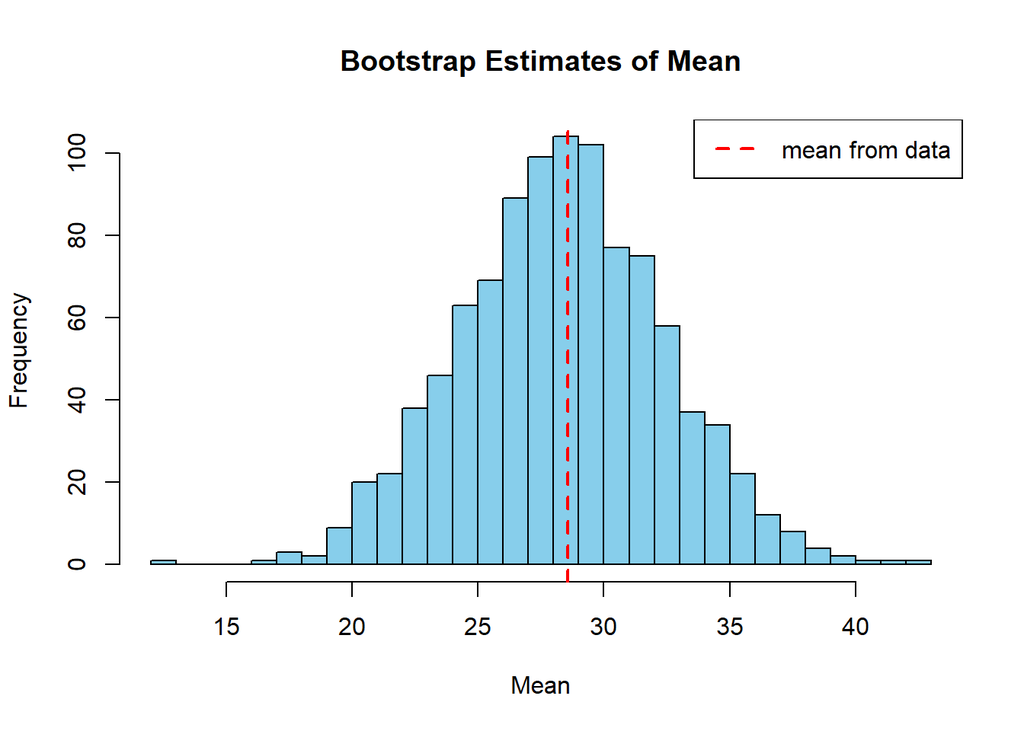

```r
# histogram of bootstrap estimates
hist(result$theta_star, breaks = 30, col = "skyblue", border = "black",
     main = "Bootstrap Estimates of Mean", xlab = "Mean")
abline(v = result$theta_hat, col = "red", lty = 2, lwd = 2)
legend("topright", legend = "mean from data", col = "red", lty = 2, lwd = 2)
```

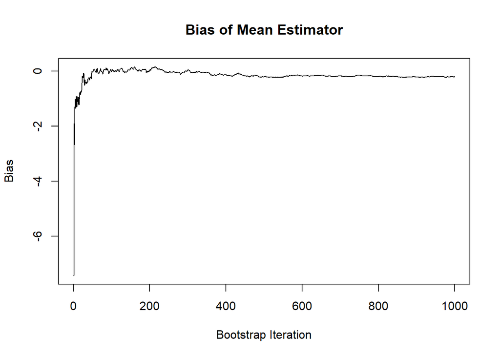

```r
# bias
running_mean <- cumsum(result$theta_star) / seq_along(result$theta_star)
plot(running_mean - result$theta_hat, type = "l",
     main = "Bias of Mean Estimator", xlab = "Bootstrap Iteration", ylab = "Bias")
```